# SimmsFishFence

Eric V

2024-10-07

# 1 Intro

Simms Creek is a small, 3rd order stream that drains an area of ~1,800 ha into the Salish Sea, near Campbell River’s Willow Point neighborhood. The lower reach of Simms Creek (~3 km of channel, east of Jubilee Road), is contained within a narrow urban green way that is bordered by residential properties. From Jubilee Road to the Inland Highway the stream is protected within [Beaver Lodge Lands](https://campbellriver.travel/news/forestry-guide-to-beaver-lodge-lands/), upstream of the Inland Highway, >1.5 km of tributary channel is located within private forest lands.

Historic fish observations indicate that Chum, Chinook, Pink and Coho Salmon have all been observed in the stream, as well as Coastal Cutthroat Trout, Rainbow Trout and Steelhead. Recent records, this dataset, suggest that Coho Salmon and Coastal Cutthroat Trout are the primary species within Simms Creek, both of which utilize the stream year round - though a small number of juvenile Chinook Salmon were identified in 2024.

[Greenways Land Trust](https://www.greenwaystrust.ca/) has supported Simms Creek Stewards for +20 years, including operation of a fish fence near the mouth of the stream since 2008. Juvenile and adult fish moving past the fence are tallied each spring and fall, respectively. The objective of this project is to explore the juvenile fence dataset. All work is being done strictly for fun and out of personal curiosity. Any feedback, input, or support is welcome. Also, I have a soft spot for Coastal Cutthroat Trout (CCT), so be warned that all analysis will be trout heavy.

# 2 Annual Fence Monitoring Effort

The Simms Creek fish fence has operated annually since 2008, with the exception of 2020-21 when operations were paused during the COVID-19 Pandemic and in the of 2023 due to striking federal government employees.

(#tab:trap effort table)Annual trap operation periods

Spring Sampling

Fall Sampling

Year

# Days Sampled

Start

End

# Days Sampled

Start

End

2008

41

Apr-21

May-31

40

Oct-14

Nov-22

2009

50

Apr-19

Jun-07

40

Oct-14

Nov-22

2010

42

Apr-19

May-30

35

Oct-23

Nov-26

2011

49

Apr-19

Jun-06

46

Oct-18

Dec-02

2012

50

Apr-16

Jun-04

50

Oct-14

Dec-02

2013

49

Apr-14

Jun-01

62

Sep-29

Dec-01

2014

45

Apr-24

Jun-07

58

Oct-04

Nov-30

2015

52

Apr-10

May-31

62

Oct-08

Dec-08

2016

63

Apr-03

Jun-04

60

Oct-07

Dec-05

2017

68

Apr-05

Jun-11

56

Oct-11

Dec-05

2018

52

Apr-21

Jun-11

58

Oct-08

Dec-04

2019

51

Apr-18

Jun-07

64

Oct-08

Dec-10

2020

0

COVID

0

2021

0

COVID

0

2022

47

Apr-28

Jun-13

37

Oct-11

Nov-16

2023

0

DFO Strike

45

Sep-26

Nov-17

2024

55

Apr-12

Jun-05

0

## 2.1 Spring Surveys

Spring surveys target out migrating juvenile Coho Salmon and also capture an impressive number of Coastal Cutthroat Trout. These surveys have started as early as Apr-03, however, most surveys (50%) don’t start until Apr-18. In each monitoring year, surveys have occurred continuously (e.g., sampling occurred daily) from Apr-28 to May-30. Surveys have continued as late as Jun-13, but most (50%) are terminated by Jun-06.

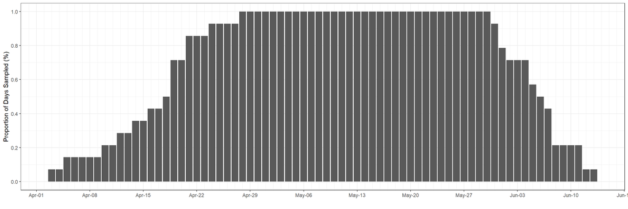

**Figure 1: Spring juvenile trap operation effort, presented as the proportion of sample years when trapping was completed on each date.**

## 2.2 Fall Surveys

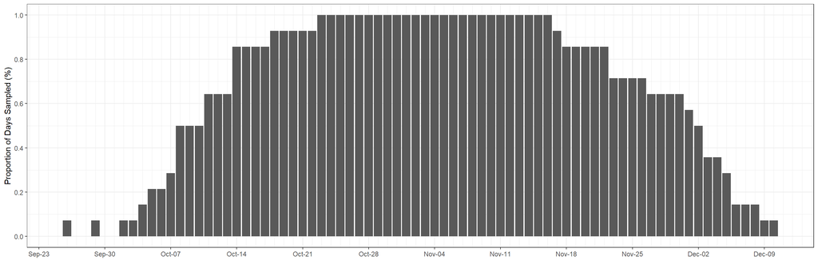

**Figure 2: Fall adult trapping effort, presented as the proportion of sample years when trapping was completed on each date.**